# İçindekiler

## Örnekler: Nesne tabanlı çizdirme yaklaşımı

Örnek yaparak daha iyi anlayacağınızı düşünüyorum vakit kaybetmeden başlayalım.

### Örnek 1: axes nesnesini kullanma

**axes** en önemli nesnelerden biridir, çünkü çoğu graik elemanı bu nesnenin içinde yer alır. O yüzden bu kısma biraz daha dikkat etmenizi ve örneği kendinizin de tekrarlamasını istiyorum.

```
--- Figür sınıfı
<class 'matplotlib.figure.Figure'>
--- Eksen sınıfı
<class 'matplotlib.axes._axes.Axes'>

 Dikkat plot çıktısı liste olarak görünecektir bu sizi şaşırtmasın :)
<class 'list'>
Line nesnesinin kendisi burada
<class 'matplotlib.lines.Line2D'>
```

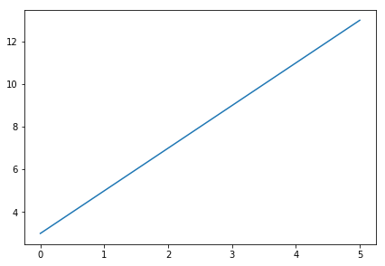

```python
# Yeni bir figure oluşturalım
fig1 = plt.figure()

print("--- Figür sınıfı")
print(type(fig1))

# bir esken ekleyelim
ax1 = fig1.add_axes([0.1,0.1,0.9,0.9])
# [sol sağ genişlik yükseklik] şeklinde parametre vermeliyiz.

print("--- Eksen sınıfı")
print(type(ax1))

# eksene basit bir çizgi ekleyelim
x = np.linspace(0,5,20)
y = 2*x + 3

l1 = ax1.plot(x,y)

print("\n Dikkat plot çıktısı liste olarak görünecektir bu sizi şaşırtmasın :) ")
print(type(l1))
print("Line nesnesinin kendisi burada ")
print(type(l1[0]))
```

> Bu arada, yukarıdaki figürü yeniden yaratmazsanız aynı isimi kullanarak figüre tekrar erişebileceğinizi söyleyeyim. Bu "notebook"'ta her adımda yeniden figürü yaratacağız. Yukarıdaki nesneye erişip onu değiştirmeyeceğiz.

### Örnek 2: Eksen içinde eksen çizdirme

Şimdi `axes` nesnesini öğrendiğimize göre, klasik yöntem ile yaparken çok zorlanacağımız birşeyler deneyelim. Mesela eksen içinde eksen çizdirerek biraz eğlenelim :)

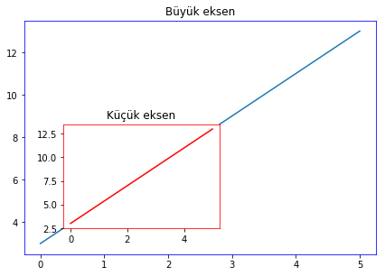

```python
# Yeni bir figure oluşturalım
fig1 = plt.figure()

# iki adet eksen ekleyelim
ax1 = fig1.add_axes([0.1,0.1,0.9,0.9])
ax2 = fig1.add_axes([0.2,0.2,0.4,0.4])

x = np.linspace(0,5,20)
y = 2*x + 3

# Büyük eksen
ax1.plot(x,y)
# küçük eksen
ax2.plot(x,y,'r')

# büyük eksenin kenar rengini mavi yapalım
ax1.spines['bottom'].set_color('blue')
ax1.spines['top'].set_color('blue')
ax1.spines['right'].set_color('blue')
ax1.spines['left'].set_color('blue')

# küçük eksenin keanrlarının rengini kırmızı
ax2.spines['bottom'].set_color('red')
ax2.spines['top'].set_color('red')
ax2.spines['right'].set_color('red')
ax2.spines['left'].set_color('red')

# Bir de title ekleyelim
ax1.set_title("Büyük eksen")
ax2.set_title("Küçük eksen")
```

### Örnek 3: Eksenlerden küçük olanı transparan yapma

Bir önceki örnek üzerinden büyük ve küçük eksene rasgele "scatter" noktalar ekleyelim ve bu noktaları biraz transparan yapalım ki çakışma olduğu zaman iki eksendeki noktaları da görebilelim.

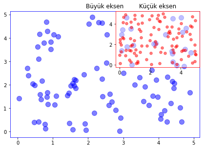

```python
# Yeni bir figure oluşturalım
fig1 = plt.figure()

# iki eksen ekleyelim
ax1 = fig1.add_axes([0.1,0.1,0.9,0.9])
ax2 = fig1.add_axes([0.6,0.6,0.4,0.4])


# büyük eksenin kenar rengini mavi yapalım
ax1.spines['bottom'].set_color('blue')
ax1.spines['top'].set_color('blue')
ax1.spines['right'].set_color('blue')
ax1.spines['left'].set_color('blue')

# küçük eksenin keanrlarının rengini kırmızı
ax2.spines['bottom'].set_color('red')
ax2.spines['top'].set_color('red')
ax2.spines['right'].set_color('red')
ax2.spines['left'].set_color('red')

# Bir de title ekleyelim
ax1.set_title("Büyük eksen")
ax2.set_title("Küçük eksen")

#---------------------------
# Scatter plot ekliyoruz
x1 = np.random.uniform(low=0, high=5, size=100)
y1 = np.random.uniform(low=0, high=5, size=100)

x2 = np.random.uniform(low=0, high=5, size=100)
y2 = np.random.uniform(low=0, high=5, size=100)

# Scatter
ax1.scatter(x1,y1,s=100,c='b',alpha=0.5)
# Buradaki alpha değeri noktaları transparan yapmak için
ax2.scatter(x2,y2,s=30,c='r',alpha=0.5)

# Buradaki alpha değeri de eksenin kendisini transparan yapıyor
ax2.patch.set_alpha(0.5)
```

ilginç değil mi? Yorulduysanız bir hava alın, çay/have için sonra devam edelim...

### Örnek 4: Tek bir figür için subplot kullanımı ve stackplot örneği

Her seferinde eksen yaratmakla uğraşmayalım diyorsak `subplots` fonksiyonunu kullanmak daha iyi olur. Bu fonksiyon hem figür hem de ekseni aynı anda yarattığı için bizi birkaç satır koddan kurtarmaktadır. Örneği daha ilginç hale getirmek için bunun üzerine çok sıklıkla karşılamadığınızı tahmin ettiğim. `stackplot` ekleyelim bir de..

> `subplots` fonksiyonu aslında birden fazla alt eksen yaratmak için kullanılmaktadır. Buraya hiç parametre vermezsek `nrows=1, ncols=1` şeklinde kullanılacak ve sadece 1 adet figüre ve eksen yaratmış olacağız.

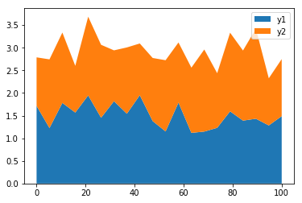

```python
# Hem figür hem de ekseni aynı anda yaratıyoruz.
fig1, ax1 = plt.subplots()

x = np.linspace(0,100,20)
y1 = np.random.uniform(low=1,high=2,size = 20)
y2 = np.random.uniform(low=1,high=2,size = 20)

# Stack plot'ta y eksenindeki değerleri üst üste ekleyerek çizdirir
ax1.stackplot(x,[y1, y2], labels=["y1","y2"]);

# legend ekleyelim
ax1.legend();
```

### Örnek 5: Çoklu figür oluşturma

Evet adım adım ilerliyoruz, ısınmaya başladık sanırım :) Diyelim ki bir figürün içinde yan yana eksenler oluşturmak istiyoruz, bu durumda yine `subplots` fonksiyonuna başvurmamız gerekecek.

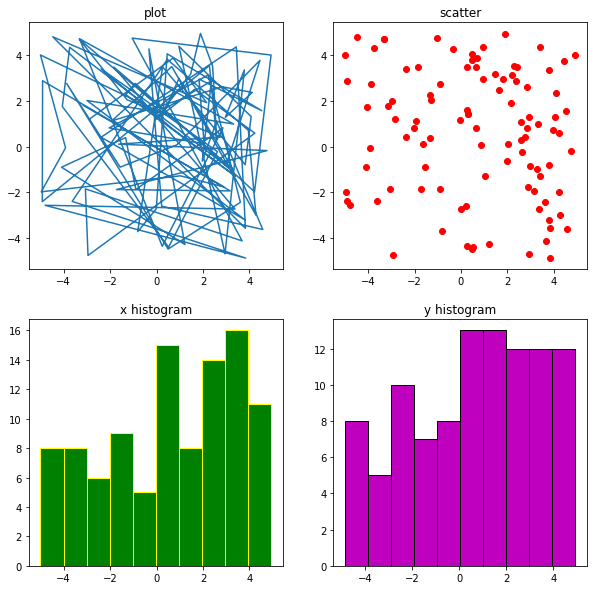

```python
# figür boyutunu biraz büyütelim
fig, axes = plt.subplots(nrows=2, ncols=2,figsize=(10,10))

# biraz veri hazırlayalım
y = np.random.uniform(low=-5,high=5,size = 100)
x = np.random.uniform(low=-5,high=5,size = 100)

# axes iki boyutlu bir matris olarak döndürülüyor
# sol üst eksene plot çizdirelim
axes[0][0].plot(x,y)
axes[0][0].set_title("plot")

# sağ üst eksene scatter çizdirelim
axes[0][1].scatter(x,y,c='r')
axes[0][1].set_title("scatter")

# sol alt eksene x histogram, sağ alt eksene y histogram
axes[1][0].hist(x,color="g",edgecolor="yellow")
axes[1][0].set_title("x histogram")
axes[1][1].hist(y,color="m",edgecolor="k")
axes[1][1].set_title("y histogram")
```

### Örnek 6: Eksenlere ve legend kısmına *LaTeX* ile denklem yazmak

$LaTeX$ genel tanımıyla bir dokümantasyon hazırlama sistemidir. Burada biz bu sistemi güzel denklemler yazmak için kullanağız. *matplotlib* LaTeX konusunda gerçekten iyidir. `$ denklem buraya $` şeklinde istediğiniz denklemi eklemeniz mümkün. LaTeX yazımı çok ayrıntılı bir konu olduğu için bu kısımda sadece örnekteki kullanımları inceleseniz yeterli.

$LaTeX$ hakkında ayrıntılı bilgi için:  
https://matplotlib.org/users/mathtext.html

> **İpucu:** Denklemleri yazdığınız string'in başına r (raw) eklemeyi unutmayın. Eklemezseniz bazen çalışmayabilir.

x'i çeşitli denklemlerde kullanıp, legend kısmına ekleyelim

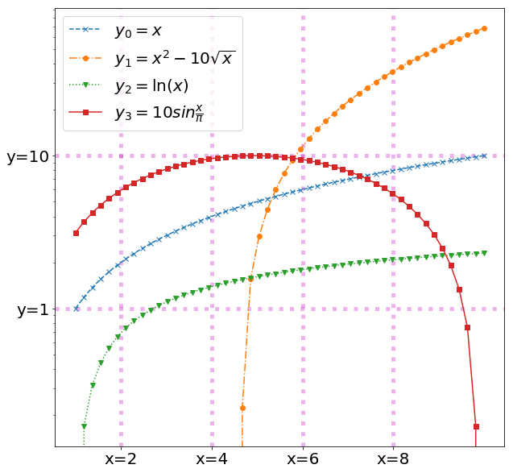

```python
fig, ax = plt.subplots(figsize = (10,10))

# x ve denklemler
x = np.linspace(1,10,50)
y0 = x
y1 = x**2-10*np.sqrt(x)
y2 = np.log(x)
y3 = 10*np.sin(x/(np.pi))

# $ işareti kullanarak denklem yazıyoruz
# Dikkat ederseniz her bir denklemin etiketini kendi içinde tanımlıyoruz.
ax.plot(x,y0, marker="x",linestyle="--", label = r"$y_0 = x$")
ax.plot(x,y1, marker="o",linestyle="-.", label = r"$y_1 = x^2-10\sqrt{x}$")
ax.plot(x,y2, marker="v",linestyle=":", label = r"$y_2 = \ln(x)$")
ax.plot(x,y3, marker="s",linestyle="-", label = r"$y_3 = 10sin{\frac{x}{\pi}} $" )

# Biraz "legend" boyutunu büyütelim
ax.legend(loc = 2, prop={'size': 20})

# y eksenini logartimic yapalım
ax.set_yscale("log")

# grid ekleyelim ve rengini farklı yapalım
ax.grid(color="m",alpha=0.3,linestyle=":",linewidth=5)

# x ve y eksenindeki tick değerlerini değiştirelim
ax.set_xticks([2,4,6,8])
ax.set_xticklabels([r'x=2',r'x=4',r'x=6',r'x=8'],fontsize=20);

ax.set_yticks([1,10])
ax.set_yticklabels([r'y=1',r'y=10'],fontsize=20);
```

> Çok çirkin bir figür oldu bence :) Umarım işin özünü kapmışsınızdır

### Örnek 7: Çift y ekseni kullanımı

Bazı durumlarda x'e bağlı iki değişkeni aynı grafikte göstermek çok zor olabilir. Örneğin birisi üssel olarak artıyor diğeri lineer artıyorsa bunların üssel olanın değeri çok büyük diğeri ise ona kıyasla çok çok küçüktür. Bu aşamda imdadımıza çift eksen kullanımı yetişecektir.

> **İpucu:** Çift eksen çizdirme `twinx` fonksiyonu kullanılarak yapılmaktadır. İsterseniz `` `twiny `` da mevcut

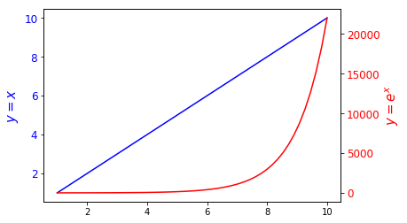

```python
fig, ax = plt.subplots()

# x ve denklemler
x = np.linspace(1,10,50)
# lineer
y1 = x
# üssel
y2 = np.exp(x)

# ilk ekseni çizdirelim
ax.plot(x,y1,"b")
# ilk y eksenin etiketini yazalım
ax.set_ylabel("$y=x$",color="b",fontsize=15)
# y eksenindeki fontu da modifye edelim
for label in ax.get_yticklabels():
    label.set_color("blue")
    label.set_fontsize(12)

# eksenin ikizini oluşturalım
ax_exp = ax.twinx()

# ikinci ekseni çizdirelim
ax_exp.plot(x,y2,"r")
# ikinci y eksenin etiketini yazalım
ax_exp.set_ylabel("$y=e^x$",color="r",fontsize=15)
for label in ax_exp.get_yticklabels():
    label.set_color("red")
    label.set_fontsize(12)
```

### Örnek 8: İki çizgi grafiğin arasını `fill_between` fonksiyonu ile doldurma

y ekseninde iki fonsiyonunuz var ve bunların arasını doldurmak istiyorusunuz öyle mi? Challenge accepted!!!

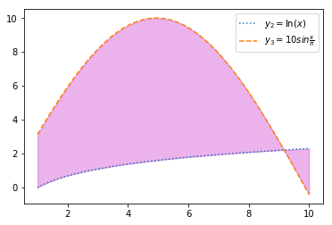

```python
# x ve denklemler
x = np.linspace(1,10,50)
y1 = np.log(x)
y2 = 10*np.sin(x/(np.pi))

fig,ax = plt.subplots()

# y'nin arasını dolduralım
ax.fill_between(x,y1,y2,color="m",alpha=0.3)
# Yukarıdaki örnekteki değerleri kullanalım
ax.plot(x,y1,":",label = r"$y_2 = \ln(x)$")
ax.plot(x,y2,"--",label = r"$y_3 = 10sin{\frac{x}{\pi}} $")
ax.legend()
```

### Örnek 9: `polar` grafik çizme

Çok ihtiyacınız olmayabilir fakat nasıl yapıldığına mutlaka bir göz atın bence.

> **İpucu:** Ekseni `polar` olarak tanımladıktan sonra grafik tipini istediğiniz gibi seçebilirsiniz.

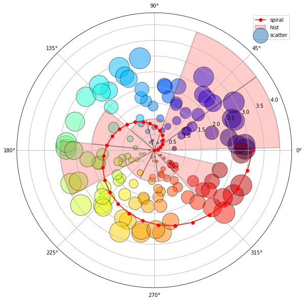

```python
# Burada subplot metodunu kullanmıyoruz
fig = plt.figure(figsize = (10,10))
# add_plot yerine add_subplot kullandık.
# Bunun avantajı add_subplot'taki
# gibi sınır tanımlamamıza gerek olmamasıdır
ax = fig.add_subplot(111,projection='polar')

# eksenler r ve theta olacak
N=150
# Rasgele sayılar üretelim
r = 3*np.random.rand(N)
# theta
theta = 2 * np.pi * np.random.rand(N)

# bir spiral çizdirelim
theta2 = np.linspace(0,2*np.pi,30)

# scatter ekleyelim
# theta'ya göre renk verelim, biraz da alpha
# Boyutunu da 200*r**2 yapalım
ax.scatter(theta,r,
           c=theta,
           alpha=0.5,
           edgecolor="k",
           s=r**2*200,
           cmap="jet",label="scatter");

# spiral ekleyelim
ax.plot(theta2,theta2/2,"r",marker="o",label="spiral");

# Histogram da olur mu dersiniz?
var = np.random.uniform(low=0,high=2*np.pi,size=20)
ax.hist(var,color="r",alpha=0.2,edgecolor="k",linewidth=2,label="hist");

ax.legend()
```

İyice karışık pizza gibi oldu, daha fazla karıştırmadan kaçalım bu örnekten.

### Örnek 10: Farklı boyutlarda subplot çizdirmek

Kimisi uzun kimisi kısa subplot çizdirmek istediniz diyelim buna da çare var üzülmeyin.

> **İpucu:** `subplot2grid` fonksiyonunu kullanarak yapıyoruz bunları. Subplot indekslemesi sol üst köşede 0,0 olacak şekilde başlıyor.

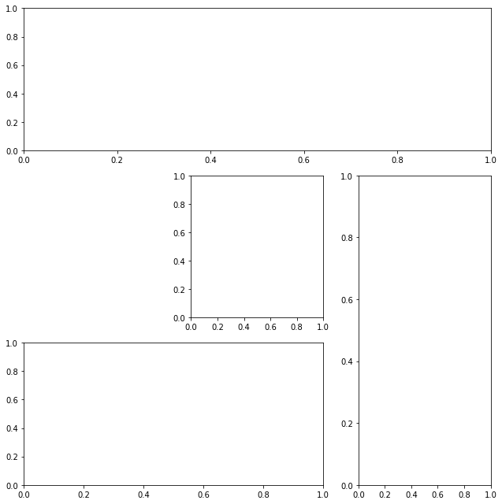

```python
fig = plt.figure(figsize=(9,9))
ax1 = plt.subplot2grid((3,3), (0,0), colspan=3)
ax2 = plt.subplot2grid((3,3), (1,2), rowspan=2)
ax3 = plt.subplot2grid((3,3), (2,0), colspan=2)
ax4 = plt.subplot2grid((3,3), (1,1))

# Layout'u biraz düzgün hale getirelim
fig.tight_layout()
```

### Örnek 11: Kontür bulma, `pcolor` gösterimi ve yatay `colorbar` çizdirme

Daha öne haritalarda eşdeğer çizgiler görmüşsünüzdür. Kontür bulma bu çizgilerin iki boyutlu düzlemde gösterilmesidir. Kontür bulmayı genelikle üç boyutlu veriler üzerinde yaparız. Bunun için ilk önce 2 boyutlu bir ızgara (grid) yaratalım ve bu ızgaranın üzerine bir fonksiyon oturtalım.

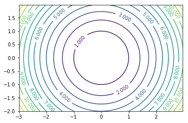

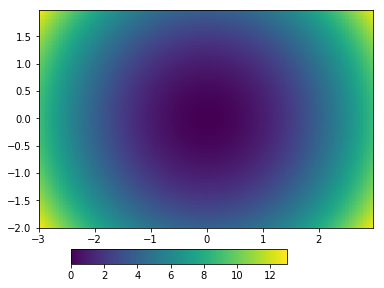

```python
delta = 0.025
x = np.arange(-3.0, 3.0, delta)
y = np.arange(-2.0, 2.0, delta)
# ızgarayı oluşturalım.
X, Y = np.meshgrid(x, y)
# iki değerin karesinin toplamını alalım
Z = X**2 + Y**2

#yeni figure oluşturuyoruz
fig,ax = plt.subplots()
# conyour çizdirelim
CS = ax.contour(X, Y, Z,levels = np.arange(0,14,1))
# Bu çizdiriğimiz kontor değerlerine  etiket atayalım
plt.clabel(CS, inline=1, fontsize=10)

# aynı örneği bir de renkli olarak gösterelim
fig1,ax1 = plt.subplots()
out = ax1.pcolor(X,Y,Z)
# bir colorbar ekleyelim
# colorbar'ın kendi ekseni vardır
col_bar = fig1.add_axes([0.2, 0, 0.5, 0.05])
fig1.colorbar(out,cax=col_bar, orientation='horizontal')
```

### Örnek 12: Üç boyutlu çizim

*matplotlib* kütüphanesinin üç boyutlu çizim için en iyi ortam olduğunu söylemek biraz güç.

Üç boyutlu çizim yapabilmek için öncelikle aşağıdaki kütüphaneyi `import` etmemiz lazım.

```python
from mpl_toolkits.mplot3d.axes3d import Axes3D
```

Şimdi üç boyutlu bir yüzey çizimi yapalım, polar grafik çiziminde olduğu gibi bunda da `projection` parametresini ayarlamamız gerekiyor.

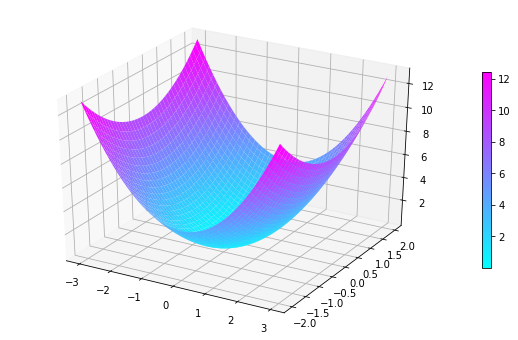

```python
fig = plt.figure(figsize=(10,6))

ax = fig.add_subplot(111,projection='3d')

# Veri hazırlayalım
delta = 0.025
x = np.arange(-3.0, 3.0, delta)
y = np.arange(-2.0, 2.0, delta)
# ızgarayı oluşturalım.
X, Y = np.meshgrid(x, y)
# iki değerin karesinin toplamını alalım
Z = X**2 + Y**2

# cool bir renk seçimi olsun :)
surf = ax.plot_surface(X,Y,Z,cmap="cool");
#colorbar ekleyelim ve biraz küçültelim shrink = 0.6 olsun
fig.colorbar(surf,shrink=0.6)
```

### Örnek 13: Üç boyutlu çizim üzerinde `contour` gösterimi ve bakış açısını değiştirme

Her eksenin izdüşümde kontür görmek ne güzel olurdu değil mi? Bunu başarmak mümkün tabii ki, hem de çok zor değil. Yukarıdaki örneği kullanalım

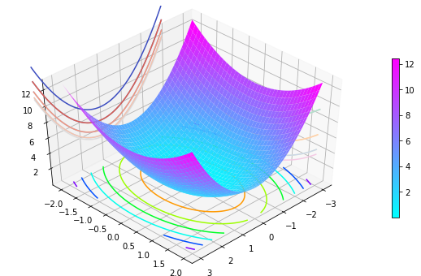

```python
fig = plt.figure(figsize=(10,6))

ax = fig.add_subplot(111,projection='3d')

# Veri hazırlayalım
delta = 0.025
x = np.arange(-3.0, 3.0, delta)
y = np.arange(-2.0, 2.0, delta)
# ızgarayı oluşturalım.
X, Y = np.meshgrid(x, y)
# iki değerin karesinin toplamını alalım
Z = X**2 + Y**2

# cool bir renk seçimi olsun :)
surf = ax.plot_surface(X,Y,Z,cmap="cool");
#colorbar ekleyelim ve biraz küçültelim shrink = 0.6 olsun
fig.colorbar(surf,shrink=0.6)

cset = ax.contour(X, Y, Z, zdir='z', offset=-0, cmap="gist_rainbow")
cset = ax.contour(X, Y, Z, zdir='x', offset=-3, cmap="Pastel2_r")
cset = ax.contour(X, Y, Z, zdir='y', offset=-3, cmap="coolwarm")

# Biraz görünümü de değiştirelim
ax.view_init(45,45)
```